# Optimize your 401-k

- Abstract
- Load Libraries
- Download Monthly Quotes
- Compute Monthly Returns
- Clustering
- PCA: Visualizing Clusters
- Chart Cumulative Returns
- Qualitative Evaluation of Clusters
- Plot Selected Funds on PCA Chart
- Mean-Var Analysis of Selected Funds
- Portfolio Analysis of Selected Funds
- Back-test Selected Portfolio
- Null Funds
- Include Null Funds
- Future

## Abstract

Allocating money across the various investment funds available in your 401-k account can be challenging. Some 401-k managers offer hundreds of funds to choose from. The large number of options makes it difficult to construct an optimal investment portfolio.

This article tackles the problem using the following strategy:

1. Reduce the number of options by sorting the funds into a set of “clusters” based on similarity between the funds' monthly rate-of-returns (i.e. funds with highly correlated monthly returns are sorted together in the same cluster).
2. Select a single “representative fund” from each cluster.
3. Combine the representative funds into an optimal investment portfolio.

Step 1 involved using K-means clustering to cluster funds based on the past 5 years of monthly returns. The optimal number of clusters (10) was decided using multiple cluster evaluation metrics. The clustering algorithm performed well, in that funds sorted themselves together as an investor might expect them to (large-cap stocks clustered together, high-yield bonds clustered together, real estate funds clustered together, etc).

Step 2 involved using mean-variance analysis to select an optimally performing fund as the “representative fund” for each cluster. In most cases the representative fund was easy to choose as it dominated the mean-variance analysis (the fund produced the best mean return at nearly the lowest volatility). In other cases, where no fund clearly dominated the cluster, the representative fund was selected by trading off return and volatility (in a somewhat arbitrary manner according to my own risk appetite).

Step 3 involved using standard mean-variance portfolio analysis to determine an optimal allocation strategy across the representative funds.

Note that this strategy generalizes to any set of assets, not just 401-k mutual funds.

**Caveat emptor**: It goes without saying that correlation does not equal causation, that past results do not guarantee future performance. This article does not constitute investment advice. Trade at your own risk.

## Load Libraries

```r
    library(tseries)                # get.hist.quote
    library(zoo)                    # coredata
    library(quadprog)               # solve.QP
    library(PerformanceAnalytics)   # chart.*
    library(dplyr)                  # mutate, arrange, filter

    source("mean-var.R")
    source("my401k-functions.R")
    source("my401k-etl.R")
    source("my401k-clustering.R")

    options(width=150)              # R results display width
    options(scipen=7)               # favor fixed notation over scientific notation
```

## Download Monthly Quotes

```r
    funds.df <- My401kEtl$loadFundList()

    #
    # zoo time-series object
    # rows: monthly quotes
    # cols: funds
    #
    quotes.zoo <- My401kEtl$loadAllTickerQuotes(funds.df)
```

```
## <simpleError in read.table(file, ...): no lines available in input>
## <simpleError in read.table(file, ...): no lines available in input>
## <simpleError in read.table(file, ...): no lines available in input>
```

```r
    #
    # print the number of monthly quotes for each fund
    #
    quote.counts <- apply( !is.na(quotes.zoo),2,sum)
    sort(quote.counts, decreasing=T)
```

```
##  ^RUA ^GSPC   IWO   IWN   IBM FNMIX PEBIX FAGIX FFRHX SPHIX PHIYX FGMNX FSTGX PDMIX PTRIX DODIX FTHRX FGOVX PIGIX PMDRX PTSAX PTTRX PGOVX PRRIX FSICX
##   193   193   193   193   193   193   193   193   193   193   193   193   193   193   193   193   193   193   193   193   193   193   193   193   193
## FFXSX FSHBX PLDIX PTLDX VFSIX PFORX PIGLX PGBIX FCVSX VCVSX DODBX VGSTX FGBLX PSTKX VDIGX VFTNX FTQGX FLCSX FTRNX DODGX VMCIX VSEQX VMGRX VASVX DFSTX
##   193   193   193   193   193   193   193   193   193   193   193   193   193   193   193   193   193   193   193   193   193   193   193   193   193
## FSLCX VSCIX FSCRX FDSCX DFFVX FRESX DFEVX DFEMX FPBFX FIEUX DFALX VTRIX DFIVX VINEX DFISX FJPNX FLATX FICDX FHKCX FSEAX VHGEX VFIJX VFIUX VFIDX VUSUX
##   193   193   193   193   193   193   193   193   193   193   193   193   193   193   193   193   193   193   193   193   193   192   192   192   192
## VWETX VSGDX VFIRX DODFX VWIAX VWENX VGIAX VMRAX VWNAX VEIRX VWILX VWEAX PRAIX VWNEX VEXRX FINPX PCRIX PAAIX  ^RLG  ^RLV FISMX FTBFX FRIFX PDIIX   AGG
##   192   192   192   190   189   189   189   189   189   186   186   183   183   183   183   176   175   174   173   173   173   172   169   162   161
## PRRSX PAUIX VIPIX PFUIX FIREX VPCCX   VWO DFEOX  RSCO VBIMX VBLLX DFVEX PELBX   HYG   IPE  ACWX FBAKX FDGKX FFDKX FBGKX FCAKX FCNKX FEXKX FGCKX FGDKX
##   160   159   158   153   149   146   143   137   135   133   133   133   121   118   117   106   105   105   105   105   105   105   105   105   105
## FDFKX FOCKX FEIKX FLCKX FLPKX FVSKX FKMCX FVLKX FIDKX FOSKX FDIKX DODWX DFGEX PFIUX DFVQX   LWC RCWGX RLBGX RFNGX RICGX RAFGX RGAGX RNGGX RMFGX RWMGX
##   105   105   105   105   105   105   105   105   105   105   105   105   104   103   102    95    93    93    93    93    93    93    93    93    93
## RLLGX RNWGX RERGX RWIGX RIGGX RNPGX FFKVX FFKCX FKVFX FFKDX FKTWX FFKEX FKTHX FFKFX FFKGX FFKHX FFKAX FDENX VBITX
##    93    93    93    93    93    93    91    91    91    91    91    91    91    91    91    91    91    68    65
```

## Compute Monthly Returns

```r
    simple.returns.zoo <- My401k$computeSimpleReturns(quotes.zoo)

    simple.returns.fees.zoo <- My401k$computeSimpleReturnsWithFees(simple.returns.zoo,
                                                                   funds.df)

    simple.returns.stats.df <- My401k$computeSimpleReturnsStats(simple.returns.zoo)
    simple.returns.fees.stats.df <- My401k$computeSimpleReturnsStats(simple.returns.fees.zoo)

    # fundsx.df <- merge(funds.df, simple.returns.stats.df, by=0, all.x=T)

    #
    # Extract the core matrix data
    # transpose: each row is a fund, each col is a monthly return
    #
    simple.returns.mat <- t( coredata(simple.returns.zoo) )
```

## Clustering

```r
    #
    # list of objects returned by kmeans()
    # one for each number-of-clusters (4:14)
    #
    km.list <- My401kClustering$generateKmeansResults(simple.returns.mat, 4:14)

    #
    # Various measures to evaluate clustering results
    # Some measures (DB, SD) suggest 9 clusters
    # Other measures (R^2, Hartigan) suggest 11 clusters
    # Go with 10?
    #
    km.eval <- My401kClustering$evaluateKmeansResults(km.list, simple.returns.mat)
    data.frame(km.eval)
```

```
##    num.clusters hartigan.score r.squared s.dbw       sd        db
## 1             4      15.653556 0.5774665   Inf 13.17162 1.3002868
## 2             5      21.889203 0.6142827   Inf 22.34053 1.4476565
## 3             6      14.726657 0.6599481   Inf 20.43790 1.2646341
## 4             7      15.595816 0.6882847   Inf 22.96410 1.2926787
## 5             8      15.270543 0.7158134   Inf 22.10195 1.1706961
## 6             9      15.380979 0.7405733   Inf 19.24300 0.9957847
## 7            10      13.151824 0.7634556   Inf 22.38347 1.0321809
## 8            11       7.451145 0.7816324   Inf 23.67971 1.0426896
## 9            12      15.188145 0.7915264   Inf 31.39795 1.1617923
## 10           13       3.190338 0.8100226   Inf 21.68068 0.9461831
## 11           14       0.000000 0.8138540   Inf 33.28570 1.1676305
```

```r
    km <- km.list[[7]]      # 10 clusters
```

## PCA: Visualizing Clusters

```r
    pca <- prcomp(simple.returns.mat,
                  center = T)

    #
    # 90% of variance is explained by first 9 principal components.
    # This also suggests using ~9 clusters, tho I can't explain why.
    #
    summary(pca)$importance[,1:11]
```

```
##                             PC1        PC2        PC3       PC4        PC5        PC6        PC7        PC8       PC9       PC10     PC11
## Standard deviation     0.116494 0.06963385 0.04603233 0.0390792 0.02995912 0.02721734 0.02498407 0.02359252 0.0211901 0.01913384 0.016124
## Proportion of Variance 0.483830 0.17287000 0.07555000 0.0544500 0.03200000 0.02641000 0.02225000 0.01984000 0.0160100 0.01305000 0.009270
## Cumulative Proportion  0.483830 0.65671000 0.73226000 0.7867000 0.81870000 0.84511000 0.86737000 0.88721000 0.9032200 0.91627000 0.925540
```

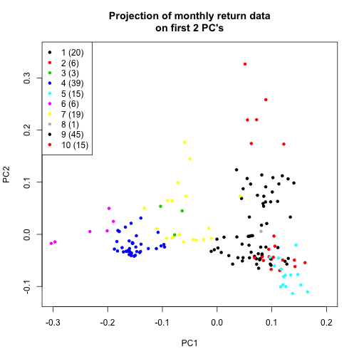

```r
    #
    # pca$x is the projection of simple.returns.mat (centered) onto the principal components.
    # Use the first two principal components to project the high-dimensional data onto a plane
    # for visualization.
    #
    proj.2d <- pca$x[,1:2]
    plot(proj.2d,
         col=km$cluster,
         pch=20,
         xlim=c(-0.3,0.2),
         ylim=c(-0.12,0.35))
    title("Projection of monthly return data\non first 2 PC's")

    #
    # legend: cluster id (# of funds in cluster)
    #
    legend.text = sapply(1:10, function(i) { paste(toString(i), " (", toString(km$size[i]), ")", sep="") })
    legend(x="topleft", legend=legend.text, col=1:10, pch=20)
```

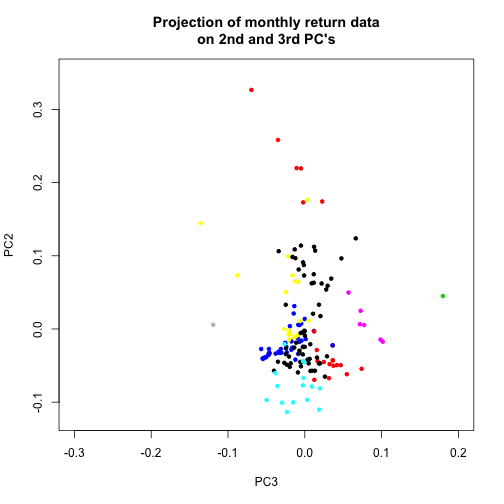

```r
    #
    # Include 3rd PC
    #
    proj.2d <- pca$x[,3:2]
    plot(proj.2d,
         col=km$cluster,
         pch=20,
         xlim=c(-0.3,0.2),
         ylim=c(-0.12,0.35))
    title("Projection of monthly return data\non 2nd and 3rd PC's")
```

## Chart Cumulative Returns

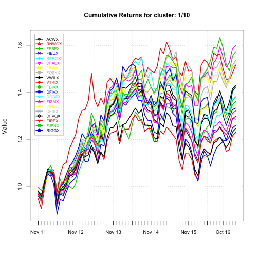

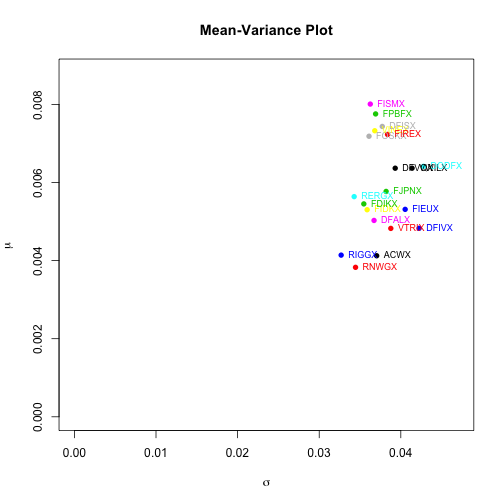

```
##    ticker                 name       asset.class               category     fod fees        mean         sd weighted.mean cum.return
## 1   FISMX   FID INTL SMALL CAP Stock Investments  Foreign Sm/Mid Growth Foreign 1.32 0.008008333 0.03625892   0.006784262   1.598915
## 2   FPBFX    FID PACIFIC BASIN Stock Investments   Diversified Pac/Asia Foreign 1.17 0.007756019 0.03691017   0.006024825   1.571251
## 3   DFISX  DFA INTL SMALL CO I Stock Investments   Foreign Sm/Mid Value Foreign 0.54 0.007435671 0.03772653   0.006428529   1.536570
## 4   VINEX VANG INTL EXPLOR INV Stock Investments  Foreign Sm/Mid Growth Foreign 0.42 0.007325119 0.03680704   0.005672022   1.528838
## 5   FOSKX       FID OVERSEAS K Stock Investments    Foreign Large Blend Foreign 0.91 0.007184319 0.03610243   0.004782383   1.517815
## 6   FIREX FID INTL REAL ESTATE Stock Investments     Global Real Estate Foreign 1.12 0.007230884 0.03837364   0.003640620   1.515081
## 7   DFVQX DFA INTL VECTOR EQ I Stock Investments   Foreign Sm/Mid Value Foreign 0.50 0.006365979 0.03931217   0.005231851   1.429861
## 8   VWILX VANG INTL GROWTH ADM Stock Investments    Foreign Large Blend Foreign 0.34 0.006366783 0.04137728   0.005138418   1.422534
## 9   DODFX DODGE & COX INTL STK Stock Investments    Foreign Large Value Foreign 0.64 0.006414258 0.04277871   0.004686562   1.421135
## 10  RERGX AF EUROPAC GROWTH R6 Stock Investments    Foreign Large Blend Foreign 0.50 0.005638068 0.03428187   0.003809751   1.381045
## 11  FJPNX            FID JAPAN Stock Investments            Japan Stock Foreign 0.80 0.005771246 0.03819850   0.004982486   1.380995
## 12  FDIKX FID DIVERSIFD INTL K Stock Investments   Foreign Large Growth Foreign 0.87 0.005451850 0.03546595   0.003071699   1.361196
## 13  FIDKX FID INTL DISCOVERY K Stock Investments    Foreign Large Blend Foreign 0.86 0.005302527 0.03587079   0.002645302   1.346999
## 14  FIEUX           FID EUROPE Stock Investments           Europe Stock Foreign 1.03 0.005312257 0.04053237   0.001956536   1.332727
## 15  DFALX DFA LARGE CAP INTL I Stock Investments    Foreign Large Blend Foreign 0.29 0.005028285 0.03671784   0.003345891   1.321214
## 16  VTRIX  VANGUARD INTL VALUE Stock Investments    Foreign Large Blend Foreign 0.46 0.004824526 0.03877321   0.002862642   1.297859
## 17  DFIVX     DFA INTL VALUE I Stock Investments    Foreign Large Value Foreign 0.63 0.004827110 0.04224156   0.003841744   1.286444
## 18  RIGGX AF INTL GTH & INC R6 Stock Investments            World Stock Foreign 0.58 0.004140316 0.03268878   0.001705685   1.259603
## 19   ACWX   INTL STOCK MKT IDX Stock Investments   International Stocks Foreign 0.09 0.004124311 0.03704054   0.002912483   1.246217
## 20  RNWGX      AF NEW WORLD R6 Stock Investments Diversified Emerg Mkts Foreign 0.65 0.003827660 0.03445153   0.002755730   1.230173
```

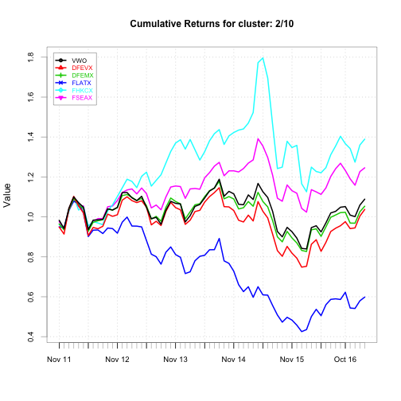

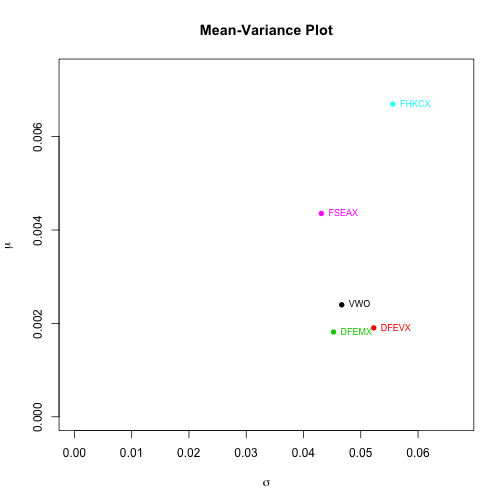

```
##   ticker                 name       asset.class               category     fod fees         mean         sd weighted.mean cum.return
## 1  FHKCX     FID CHINA REGION Stock Investments  Pacific/Asia ex-Japan Foreign 0.99  0.006696411 0.05559823   0.004963179  1.3892725
## 2  FSEAX    FID EMERGING ASIA Stock Investments  Pacific/Asia ex-Japan Foreign 1.09  0.004354461 0.04311653   0.003826233  1.2457101
## 3    VWO EMERGING MKT STK IDX Stock Investments Emerging Markets Stock Foreign 0.12  0.002398544 0.04667392   0.002788997  1.0887148
## 4  DFEMX DFA EMERGING MARKETS Stock Investments Diversified Emerg Mkts Foreign 0.67  0.001815558 0.04524461   0.002093522  1.0534036
## 5  DFEVX DFA EMERG MKTS VALUE Stock Investments Diversified Emerg Mkts Foreign 0.66  0.001903732 0.05227060   0.003192541  1.0372809
## 6  FLATX    FID LATIN AMERICA Stock Investments    Latin America Stock Foreign 1.13 -0.006153835 0.06095298  -0.003821912  0.5983067
```

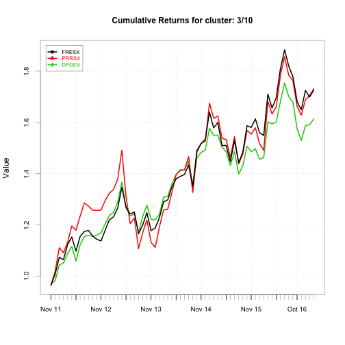

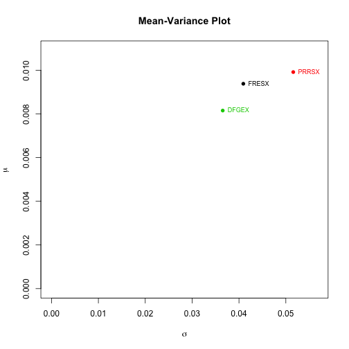

```
##   ticker                 name       asset.class           category      fod fees        mean         sd weighted.mean cum.return
## 1  PRRSX PIM RE REAL RET INST Stock Investments        Real Estate Domestic 0.94 0.009917391 0.05157974   0.008208414   1.730727
## 2  FRESX FID REAL ESTATE INVS Stock Investments        Real Estate Domestic 0.78 0.009382524 0.04092476   0.008054784   1.726088
## 3  DFGEX DFA GLOB REAL ESTATE Stock Investments Global Real Estate  Foreign 0.38 0.008154751 0.03653041   0.006350488   1.613179
```

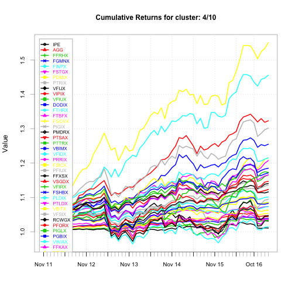

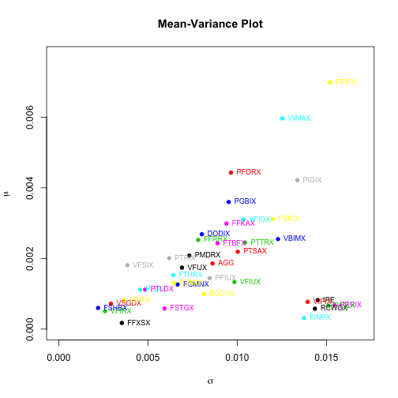

```
##    ticker                 name              asset.class               category      fod fees         mean          sd  weighted.mean cum.return
## 1   FRIFX  FID REAL ESTATE INC        Stock Investments            Real Estate Domestic 0.83 0.0069889660 0.015194372  0.00563444089   1.550447
## 2   VWIAX   VANG WELLESLEY ADM Blended Fund Investments    Conservative Alloc. Domestic 0.16 0.0059618837 0.012522198  0.00496981670   1.455778
## 3   PFORX   PIM FOR BD US$HG I         Bond Investments             World Bond  Foreign 0.51 0.0044295266 0.009643644  0.00358972237   1.323065
## 4   PIGIX PIM INVT GRD BD INST         Bond Investments Intermediate-Term Bond Domestic 0.53 0.0042146756 0.013360629  0.00325803239   1.301557
## 5   PGBIX  PIM GLOB BD US$HG I         Bond Investments             World Bond  Foreign 0.57 0.0035975493 0.009518622  0.00288342480   1.254815
## 6   VFIDX VANG INTM INV GR ADM         Bond Investments Intermediate-Term Bond Domestic 0.10 0.0031020735 0.010348725  0.00245480796   1.215142
## 7   FSICX FID STRATEGIC INCOME         Bond Investments       Multisector Bond Domestic 0.71 0.0031156424 0.011989265  0.00280640117   1.214799
## 8   FFKAX FID FREEDOM K INCOME Blended Fund Investments  Target-Date 2005-2055 Domestic 0.44 0.0029885359 0.009392257  0.00272613374   1.207095
## 9   DODIX   DODGE & COX INCOME         Bond Investments Intermediate-Term Bond Domestic 0.43 0.0026859626 0.008013318  0.00221829538   1.184899
## 10  FFRHX  FID FLOAT RT HI INC         Bond Investments        High Yield Bond Domestic 0.70 0.0025250215 0.007809550  0.00242450818   1.172912
## 11  VBIMX  VANG INTM BOND INST         Bond Investments Intermediate-Term Bond Domestic 0.06 0.0025491918 0.012277887  0.00193527014   1.171400
## 12  PTTRX    PIM TOTAL RT INST         Bond Investments Intermediate-Term Bond Domestic 0.47 0.0024483473 0.010434388  0.00157761690   1.165416
## 13  FTBFX       FID TOTAL BOND         Bond Investments Intermediate-Term Bond Domestic 0.45 0.0024324174 0.008888990  0.00214153977   1.165327
## 14  PTSAX  PIM TOT RT III INST         Bond Investments Intermediate-Term Bond Domestic 0.55 0.0021900155 0.010026048  0.00140055757   1.146653
```

[output cut: 25 more lines]

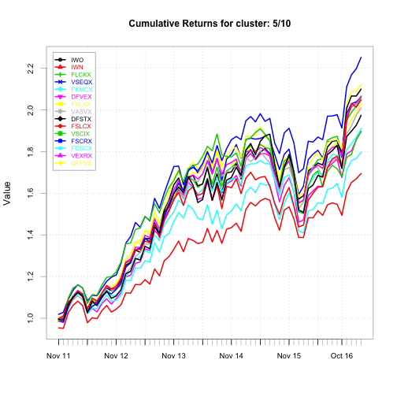

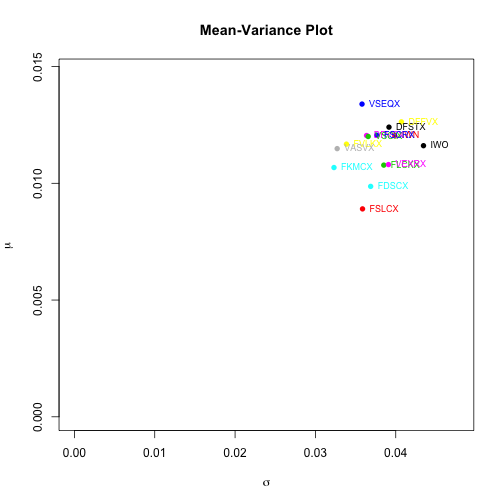

```
##    ticker                 name       asset.class         category      fod fees        mean         sd weighted.mean cum.return
## 1   VSEQX    VANG STRATEGIC EQ Stock Investments    Mid-Cap Blend Domestic 0.21 0.013392849 0.03580194   0.012079258   2.252092
## 2   DFFVX  DFA US TARGET VALUE Stock Investments      Small Value Domestic 0.37 0.012630401 0.04070270   0.011247103   2.121909
## 3   DFSTX   DFA US SMALL CAP I Stock Investments      Small Blend Domestic 0.37 0.012405009 0.03915674   0.011197248   2.099688
## 4   DFVEX   DFA US VECTOR EQ I Stock Investments    Mid-Cap Value Domestic 0.32 0.012046270 0.03636835   0.010491376   2.065672
## 5   FSCRX FID SM CAP DISCOVERY Stock Investments     Small Growth Domestic 1.01 0.012057087 0.03764231   0.009438955   2.061308
## 6   VSCIX VANG SM CAP IDX INST Stock Investments      Small Blend Domestic 0.07 0.012004291 0.03657015   0.010475394   2.058969
## 7     IWN  SMALL-CAP VALUE IDX Stock Investments Small-Cap Stocks Domestic 0.05 0.012038611 0.03987122   0.011547559   2.048077
## 8   FVLKX          FID VALUE K Stock Investments    Mid-Cap Value Domestic 0.73 0.011677077 0.03386113   0.009364015   2.028614
## 9   VASVX  VANG SELECTED VALUE Stock Investments    Mid-Cap Value Domestic 0.39 0.011485034 0.03270800   0.010033983   2.008978
## 10    IWO SMALL-CAP GROWTH IDX Stock Investments Small-Cap Stocks Domestic 0.05 0.011610689 0.04345271   0.010034932   1.973455
## 11  FKMCX  FID MID CAP STOCK K Stock Investments   Mid-Cap Growth Domestic 0.61 0.010674784 0.03231120   0.008900193   1.910069
## 12  FLCKX FID LEVERGD CO STK K Stock Investments    Mid-Cap Blend Domestic 0.67 0.010778360 0.03851043   0.007360984   1.896458
## 13  VEXRX    VANG EXPLORER ADM Stock Investments     Small Growth Domestic 0.35 0.010801926 0.03909502   0.009228871   1.896288
## 14  FDSCX   FID STK SEL SM CAP Stock Investments     Small Growth Domestic 0.77 0.009867684 0.03687584   0.008897108   1.796836
## 15  FSLCX  FID SMALL CAP STOCK Stock Investments      Small Blend Domestic 1.00 0.008903874 0.03586352   0.008658896   1.694461
```

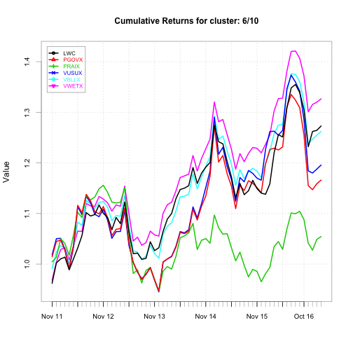

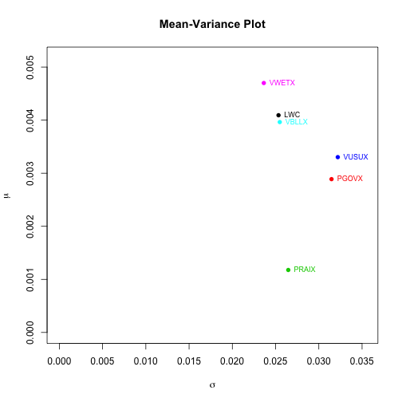

```
##   ticker                 name      asset.class        category      fod  fees        mean         sd weighted.mean cum.return
## 1  VWETX   VANG LT INV GR ADM Bond Investments  Long-Term Bond Domestic 0.120 0.004699714 0.02363835  0.0041335657   1.326523
## 2    LWC  LONG-TERM CORP BOND Bond Investments           Bonds Domestic 0.050 0.004092539 0.02534011  0.0039758790   1.272850
## 3  VBLLX  VANG LT BOND IDX IS Bond Investments  Long-Term Bond Domestic 0.060 0.003963894 0.02548397  0.0033764565   1.262165
## 4  VUSUX VANG LT TREASURY ADM Bond Investments Long Government Domestic 0.100 0.003303096 0.03219189  0.0025821308   1.195673
## 5  PGOVX  PIM LT US GOVT INST Bond Investments Long Government Domestic 0.535 0.002888620 0.03146758  0.0020319097   1.166074
## 6  PRAIX PIM RL RT ASSET INST Bond Investments Long Government Domestic 0.730 0.001177063 0.02646795  0.0005994774   1.054461
```

[8 more figures not shown]

```
##    ticker                 name       asset.class       category      fod fees        mean         sd weighted.mean cum.return
## 1   FOCKX            FID OTC K Stock Investments   Large Growth Domestic 0.72 0.013316089 0.04486589   0.013228319   2.190017
## 2   FGCKX      FID GROWTH CO K Stock Investments   Large Growth Domestic 0.77 0.012680783 0.03951147   0.011586422   2.133552
## 3   RGAGX AF GRTH FUND AMER R6 Stock Investments   Large Growth Domestic 0.33 0.012214871 0.03128913   0.010736720   2.109901
## 4   FBGKX   FID BLUE CHIP GR K Stock Investments   Large Growth Domestic 0.78 0.011890846 0.03648867   0.010224531   2.044399
## 5   RNGGX    AF NEW ECONOMY R6 Stock Investments   Large Growth Domestic 0.46 0.011755143 0.03437120   0.008873793   2.036292
## 6   VMRAX VANG MORGAN GRTH ADM Stock Investments   Large Growth Domestic 0.27 0.011034211 0.03319755   0.009635517   1.950688
## 7   FTRNX            FID TREND Stock Investments   Large Growth Domestic 0.77 0.010963543 0.03312606   0.009482518   1.942159
## 8   FGDKX    FID GROWTH DISC K Stock Investments   Large Growth Domestic 0.64 0.010871480 0.03316878   0.009194748   1.930654
## 9   FCAKX     FID CAP APPREC K Stock Investments   Large Growth Domestic 0.72 0.010726402 0.03403416   0.008237667   1.909517
## 10  FCNKX     FID CONTRAFUND K Stock Investments   Large Growth Domestic 0.61 0.010579308 0.02970424   0.008916782   1.908203
## 11   RSCO    SMALL/MID-CAP IDX Stock Investments Mid-Cap Stocks Domestic 0.04 0.010194552 0.03477078   0.007344871   1.843049
## 12  FTQGX    FID FOCUSED STOCK Stock Investments   Large Growth Domestic 0.73 0.009502263 0.03366546   0.007141313   1.767977
## 13  FDFKX   FID INDEPENDENCE K Stock Investments   Large Growth Domestic 0.78 0.009716320 0.04073491   0.007189493   1.762457
## 14  RLLGX AF SMALLCAP WORLD R6 Stock Investments   Small Growth Domestic 0.71 0.009402126 0.03487044   0.007558527   1.752182
## 15  VMGRX VANG MIDCAP GRTH INV Stock Investments Mid-Cap Growth Domestic 0.43 0.009379577 0.03488031   0.006826586   1.749643
```

```r
    #
    # list of vectors of ticker symbols
    #
    cluster.tickers.list <- My401kClustering$getClusterTickersList( km )

    #
    # list of lists of funds
    #
    cluster.funds.list <- My401kClustering$getClusterFundsList( cluster.tickers.list, funds.df)

    My401k$chartCumulativeReturns( simple.returns.fees.zoo,
                                   simple.returns.fees.stats.df,
                                   cluster.tickers.list,
                                   cluster.funds.list )
```

## Plot Selected Funds on PCA Chart

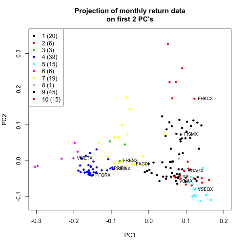

```r
    selected.funds.vec <- c( "FISMX",
                             "FHKCX",
                             "FRESX",
                             "VWIAX",
                             "FRIFX",
                             "PFORX",
                             "VSEQX",
                             "VWETX",
                             "FAGIX",
                             "VGIAX",
                             "RGAGX")

    #
    # Highlight selected funds on PCA chart
    #
    proj.2d <- pca$x[,1:2]
    plot(proj.2d,
         col=km$cluster,
         pch=20,
         xlim=c(-0.3,0.2),
         ylim=c(-0.12,0.35))
    title("Projection of monthly return data\non first 2 PC's")

    #
    # legend: cluster id (# of funds in cluster)
    #
    legend.text = sapply(1:10, function(i) { paste(toString(i), " (", toString(km$size[i]), ")", sep="") })
    legend(x="topleft", legend=legend.text, col=1:10, pch=20)

    #
    # label selected funds
    #
    proj.2d.selected.funds <- proj.2d[ selected.funds.vec, ]
    text(x=proj.2d.selected.funds[,1],
         y=proj.2d.selected.funds[,2],
         labels=selected.funds.vec,
         pos=4,
         cex=0.75)
```

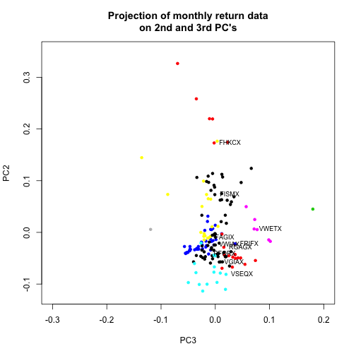

```r
    #
    # Include 3rd PC
    #
    proj.2d <- pca$x[,3:2]
    plot(proj.2d,
         col=km$cluster,
         pch=20,
         xlim=c(-0.3,0.2),
         ylim=c(-0.12,0.35))
    title("Projection of monthly return data\non 2nd and 3rd PC's")

    #
    # label selected funds
    #
    proj.2d.selected.funds <- proj.2d[ selected.funds.vec, ]
    text(x=proj.2d.selected.funds[,1],
         y=proj.2d.selected.funds[,2],
         labels=selected.funds.vec,
         pos=4,
         cex=0.75)
```

```r
    #
    # Remove FRIFX and VWIAX (not representative of cluster 4)
    #
    selected.funds.vec <- c( "FISMX",
                             "FHKCX",
                             "FRESX",
                             "PFORX",
                             "VSEQX",
                             "VWETX",
                             "FAGIX",
                             "VGIAX",
                             "RGAGX")
```

## Mean-Var Analysis of Selected Funds

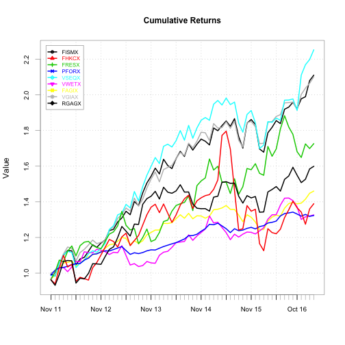

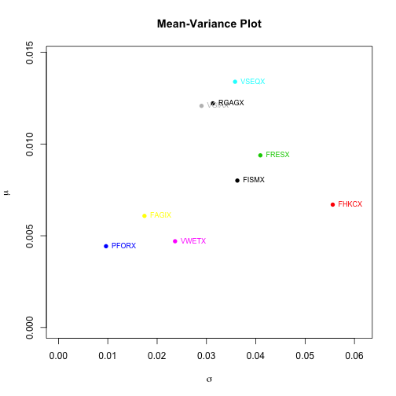

```
##   ticker                 name       asset.class              category      fod fees        mean          sd weighted.mean cum.return
## 1  VSEQX    VANG STRATEGIC EQ Stock Investments         Mid-Cap Blend Domestic 0.21 0.013392849 0.035801937   0.012079258   2.252092
## 2  RGAGX AF GRTH FUND AMER R6 Stock Investments          Large Growth Domestic 0.33 0.012214871 0.031289127   0.010736720   2.109901
## 3  VGIAX  VANG GRTH & INC ADM Stock Investments           Large Blend Domestic 0.23 0.012079700 0.028999891   0.010314855   2.101015
## 4  FRESX FID REAL ESTATE INVS Stock Investments           Real Estate Domestic 0.78 0.009382524 0.040924762   0.008054784   1.726088
## 5  FISMX   FID INTL SMALL CAP Stock Investments Foreign Sm/Mid Growth  Foreign 1.32 0.008008333 0.036258920   0.006784262   1.598915
## 6  FAGIX FID CAPITAL & INCOME  Bond Investments       High Yield Bond Domestic 0.75 0.006081848 0.017434115   0.005342495   1.460166
## 7  FHKCX     FID CHINA REGION Stock Investments Pacific/Asia ex-Japan  Foreign 0.99 0.006696411 0.055598231   0.004963179   1.389272
## 8  VWETX   VANG LT INV GR ADM  Bond Investments        Long-Term Bond Domestic 0.12 0.004699714 0.023638350   0.004133566   1.326523
## 9  PFORX   PIM FOR BD US$HG I  Bond Investments            World Bond  Foreign 0.51 0.004429527 0.009643644   0.003589722   1.323065
```

```r
    #
    # Filter selected funds from the returns data
    #
    selected.returns.zoo <- simple.returns.fees.zoo[, selected.funds.vec]
    selected.returns.stats.df <- simple.returns.fees.stats.df[ selected.funds.vec, ]
    selected.funds.df <- funds.df[ selected.funds.vec, ]

    My401k$generateReturnsCharts( selected.returns.zoo,
                                  selected.returns.stats.df,
                                  selected.funds.df )
```

## Portfolio Analysis of Selected Funds

Note: current risk-free rate (US10YR=2.45%, mid-Feb 2017) found [here](https://www.treasury.gov/resource-center/data-chart-center/interest-rates/Pages/TextView.aspx?data=yield).

```r
    #
    # build the efficient frontier (no shorting!).
    # First calc the GMV portfolio.
    # Then generate EFF portfolios from the GMV mean/var to max(asset-mean)
    #
    portfolio <- MeanVar$initPortfolio(asset.vec=as.character(selected.returns.stats.df$ticker),
                                       mu.vec=selected.returns.stats.df$mean,
                                       stdev.vec=selected.returns.stats.df$sd,
                                       Sigma.mat=coredata( cov( selected.returns.zoo )),
                                       tan.rf.rate=(2.45^(1/12) - 1)/100 )      # monthly rate assuming monthly compounding

    portfolio <- MeanVar$buildPortfolio.noShort( portfolio )
    portfolio
```

```
## $asset.vec
## [1] "FISMX" "FHKCX" "FRESX" "PFORX" "VSEQX" "VWETX" "FAGIX" "VGIAX" "RGAGX"
##
## $mu.vec
## [1] 0.008008333 0.006696411 0.009382524 0.004429527 0.013392849 0.004699714 0.006081848 0.012079700 0.012214871
##
## $stdev.vec
## [1] 0.036258920 0.055598231 0.040924762 0.009643644 0.035801937 0.023638350 0.017434115 0.028999891 0.031289127
##
## $Sigma.mat
##               FISMX         FHKCX        FRESX         PFORX          VSEQX           VWETX         FAGIX           VGIAX           RGAGX
## FISMX 0.00131470929 0.00139940172 0.0004952337 0.00003795873  0.00090924730  0.000039017687 0.00047918001  0.000746832282  0.000926053051
## FHKCX 0.00139940172 0.00309116333 0.0005333249 0.00003191556  0.00105224601  0.000113723559 0.00060998251  0.000867684415  0.001140031349
## FRESX 0.00049523371 0.00053332486 0.0016748361 0.00022738131  0.00063207428  0.000590706449 0.00034740656  0.000535341449  0.000497084698
## PFORX 0.00003795873 0.00003191556 0.0002273813 0.00009299988  0.00004750245  0.000182111809 0.00006061308  0.000049963439  0.000033545472
## VSEQX 0.00090924730 0.00105224601 0.0006320743 0.00004750245  0.00128177867 -0.000013486437 0.00048438656  0.000946382189  0.001002183346
## VWETX 0.00003901769 0.00011372356 0.0005907064 0.00018211181 -0.00001348644  0.000558771578 0.00014162688 -0.000005333511 -0.000004618167
## FAGIX 0.00047918001 0.00060998251 0.0003474066 0.00006061308  0.00048438656  0.000141626878 0.00030394837  0.000388639886  0.000452026046
## VGIAX 0.00074683228 0.00086768441 0.0005353414 0.00004996344  0.00094638219 -0.000005333511 0.00038863989  0.000840993660  0.000840004101
## RGAGX 0.00092605305 0.00114003135 0.0004970847 0.00003354547  0.00100218335 -0.000004618167 0.00045202605  0.000840004101  0.000979009476
##
## $tan.rf.rate
## [1] 0.0007753282
##
## $gmv.w.vec
## [1] -1.734723e-18  6.955017e-19 -5.262212e-18  8.979525e-01  9.511318e-18 -9.111112e-18  7.778163e-02  4.384006e-18  2.426586e-02
##
## $gmv.er
## [1] 0.004746965
##
## $gmv.stdev
## [1] 0.009435998
##
## $eff.w.mat
##                [,1]          [,2]          [,3]          [,4]          [,5]          [,6]          [,7]          [,8]          [,9]         [,10]
## FISMX  0.000000e+00 -4.699429e-18 -6.654528e-18  0.000000e+00  0.000000e+00  2.775558e-17 -9.695782e-18  6.539299e-17 -4.886209e-17 -3.702762e-17
## FHKCX  6.955017e-19  1.438786e-18  0.000000e+00  6.845862e-20  0.000000e+00 -1.387779e-17  3.462931e-18  5.051696e-18  6.192933e-18  6.491368e-18
## FRESX -1.046613e-18 -1.465608e-17 -2.787196e-17 -4.108784e-17 -2.903863e-17 -6.819188e-17 -2.161989e-18  1.387779e-17  0.000000e+00  0.000000e+00
## PFORX  8.979525e-01  8.851320e-01  8.097817e-01  7.344315e-01  6.600374e-01  5.869396e-01  5.138418e-01  4.223915e-01  3.064529e-01  1.905144e-01
## VSEQX  3.521160e-18  1.434802e-17  2.634245e-17  0.000000e+00  5.804957e-03  1.947925e-02  3.315354e-02  4.561830e-02  5.646916e-02  6.732002e-02
```

[output cut: 18 more lines]

```
##
## $eff.stdev.vec
##  [1] 0.009435998 0.009622501 0.010273187 0.011311659 0.012642456 0.014181606 0.015868217 0.017657144 0.019498641 0.021374796 0.023277232 0.025210039
## [13] 0.027273339 0.029467646 0.032119412
##
## $tan.w.vec
## [1] -1.078104e-17 -3.981494e-20 -9.200674e-18  7.487291e-01  0.000000e+00  9.695711e-17 -5.699275e-17  1.404520e-01  1.108189e-01
##
## $tan.er
##             [,1]
## [1,] 0.006366772
##
## $tan.stdev
##            [,1]
## [1,] 0.01108929
```

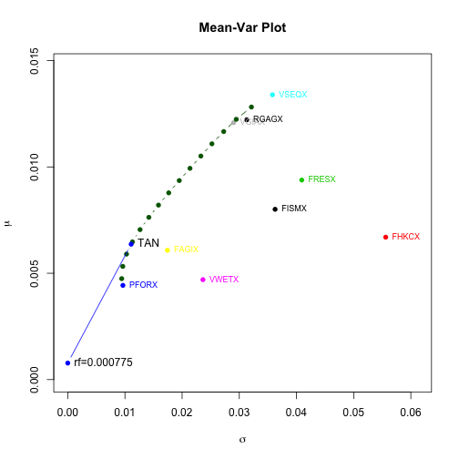

```r
    #
    # Generate the mean-var plot
    #
    MeanVar$plotPortfolio( portfolio )
```

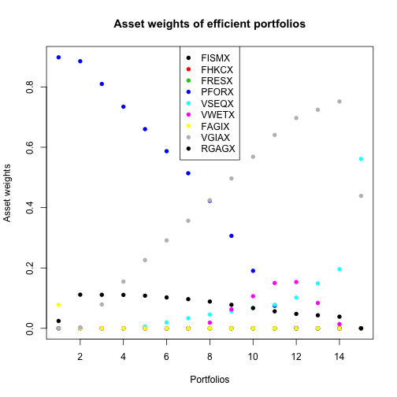

```r
    #
    # Plot and list asset weights
    #
    MeanVar$plotEffAssetWeights( portfolio, main="Asset weights of efficient portfolios" )
```

```r
    MeanVar$printEffPortfolios( portfolio )
```

```
##         [,1]   [,2]   [,3]   [,4]   [,5]   [,6]   [,7]   [,8]   [,9]  [,10]  [,11]  [,12]  [,13]  [,14]  [,15]
## FISMX 0.0000 0.0000 0.0000 0.0000 0.0000 0.0000 0.0000 0.0000 0.0000 0.0000 0.0000 0.0000 0.0000 0.0000 0.0000
## FHKCX 0.0000 0.0000 0.0000 0.0000 0.0000 0.0000 0.0000 0.0000 0.0000 0.0000 0.0000 0.0000 0.0000 0.0000 0.0000
## FRESX 0.0000 0.0000 0.0000 0.0000 0.0000 0.0000 0.0000 0.0000 0.0000 0.0000 0.0000 0.0000 0.0000 0.0000 0.0000
## PFORX 0.9000 0.8900 0.8100 0.7300 0.6600 0.5900 0.5100 0.4200 0.3100 0.1900 0.0700 0.0000 0.0000 0.0000 0.0000
## VSEQX 0.0000 0.0000 0.0000 0.0000 0.0100 0.0200 0.0300 0.0500 0.0600 0.0700 0.0800 0.1000 0.1500 0.2000 0.5600
## VWETX 0.0000 0.0000 0.0000 0.0000 0.0000 0.0000 0.0000 0.0200 0.0600 0.1100 0.1500 0.1500 0.0800 0.0100 0.0000
## FAGIX 0.0800 0.0000 0.0000 0.0000 0.0000 0.0000 0.0000 0.0000 0.0000 0.0000 0.0000 0.0000 0.0000 0.0000 0.0000
## VGIAX 0.0000 0.0000 0.0800 0.1500 0.2300 0.2900 0.3600 0.4200 0.5000 0.5700 0.6400 0.7000 0.7200 0.7500 0.4400
## RGAGX 0.0200 0.1100 0.1100 0.1100 0.1100 0.1000 0.1000 0.0900 0.0800 0.0700 0.0600 0.0500 0.0400 0.0400 0.0000
## er    0.0047 0.0053 0.0059 0.0065 0.0071 0.0076 0.0082 0.0088 0.0094 0.0099 0.0105 0.0111 0.0117 0.0122 0.0128
## stdev 0.0094 0.0096 0.0103 0.0113 0.0126 0.0142 0.0159 0.0177 0.0195 0.0214 0.0233 0.0252 0.0273 0.0295 0.0321
```

## Back-test Selected Portfolio

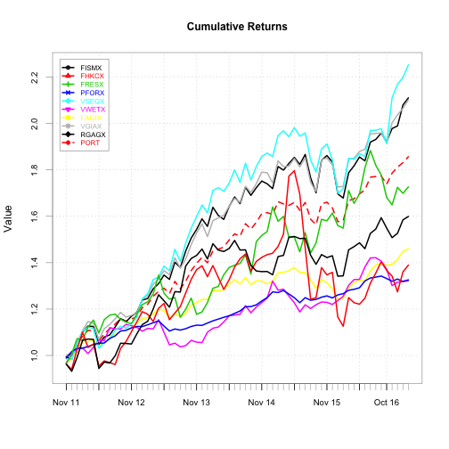

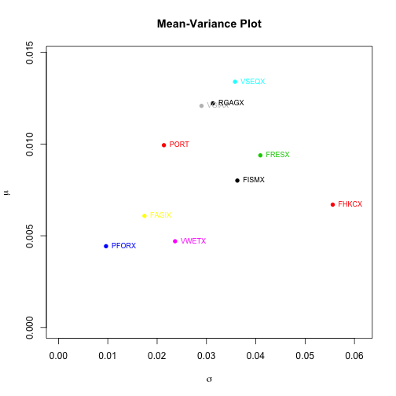

```r
    #
    # selected efficient portfolio #10
    #
    portfolio$w.vec <- portfolio$eff.w.mat[,10]

    #
    # Generate monthly portfolio returns.
    #
    # selected.returns.zoo contains the asset returns.
    # portfolio$w.vec contains the asset weights.
    #  (n x k) * (k x 1) -> (n x 1)
    # dot each row (row=monthly return, column=asset)
    # with the weight vector
    # to get the portfolio's monthly returns
    #
    port.returns.zoo <- zoo( selected.returns.zoo %*% portfolio$w.vec,
                             order.by=index(selected.returns.zoo))
    colnames(port.returns.zoo) <- c("PORT")

    #
    # Merge portfolio returns with individual asset returns
    #
    port.returns.zoo <- merge(selected.returns.zoo, port.returns.zoo)
    port.returns.stats.df <- My401k$computeSimpleReturnsStats( port.returns.zoo )   # dup effort here but oh well

    #
    # Plot cum returns and mean var of the portfolio + individual assets
    #
    My401k$plotCumReturnsAndMeanVar( port.returns.zoo,
                                     port.returns.stats.df,
                                     lty=c(rep(1,ncol(selected.returns.zoo)), 2) )
```

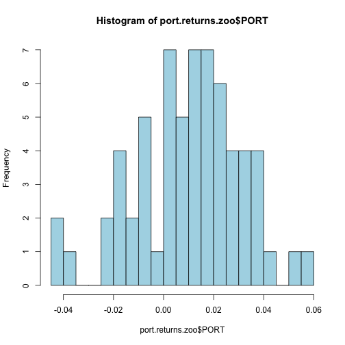

```r
    #
    # Plot histogram of just port returns
    #
    hist(port.returns.zoo$PORT,
         breaks=20,
         col="lightblue")
```

## Null Funds

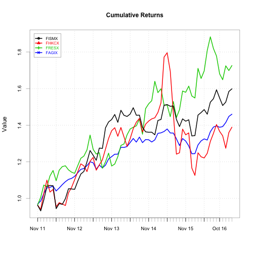

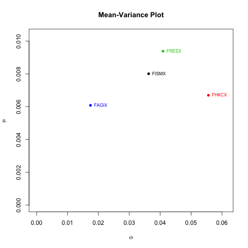

```
##   ticker                 name       asset.class              category      fod fees        mean         sd weighted.mean cum.return
## 1  FRESX FID REAL ESTATE INVS Stock Investments           Real Estate Domestic 0.78 0.009382524 0.04092476   0.008054784   1.726088
## 2  FISMX   FID INTL SMALL CAP Stock Investments Foreign Sm/Mid Growth  Foreign 1.32 0.008008333 0.03625892   0.006784262   1.598915
## 3  FAGIX FID CAPITAL & INCOME  Bond Investments       High Yield Bond Domestic 0.75 0.006081848 0.01743412   0.005342495   1.460166
## 4  FHKCX     FID CHINA REGION Stock Investments Pacific/Asia ex-Japan  Foreign 0.99 0.006696411 0.05559823   0.004963179   1.389272
```

```r
    #
    # 4 funds always have 0 allocation
    # I want to include them anyway, for diversification
    # How to do?
    # Steal equal % from all other allocations
    # divvy among the 4 - but how? mean-var analysis on just the 4?
    #
    #
    null.funds.vec <- c("FISMX", "FHKCX", "FRESX", "FAGIX")

    #
    # Filter selected funds from the returns data
    #
    null.returns.zoo <- simple.returns.fees.zoo[, null.funds.vec]
    null.returns.stats.df <- simple.returns.fees.stats.df[ null.funds.vec, ]
    null.funds.df <- funds.df[ null.funds.vec, ]

    My401k$generateReturnsCharts( null.returns.zoo,
                                  null.returns.stats.df,
                                  null.funds.df )
```

```r
    #
    # build the efficient frontier (no shorting!).
    #
    null.portfolio <- MeanVar$initPortfolio(asset.vec=as.character(null.returns.stats.df$ticker),
                                            mu.vec=null.returns.stats.df$mean,
                                            stdev.vec=null.returns.stats.df$sd,
                                            Sigma.mat=coredata( cov( null.returns.zoo )),
                                            tan.rf.rate=(2.45^(1/12) - 1)/100 )

    null.portfolio <- MeanVar$buildPortfolio.noShort( null.portfolio )
    null.portfolio
```

```
## $asset.vec
## [1] "FISMX" "FHKCX" "FRESX" "FAGIX"
##
## $mu.vec
## [1] 0.008008333 0.006696411 0.009382524 0.006081848
##
## $stdev.vec
## [1] 0.03625892 0.05559823 0.04092476 0.01743412
##
## $Sigma.mat
##              FISMX        FHKCX        FRESX        FAGIX
## FISMX 0.0013147093 0.0013994017 0.0004952337 0.0004791800
## FHKCX 0.0013994017 0.0030911633 0.0005333249 0.0006099825
## FRESX 0.0004952337 0.0005333249 0.0016748361 0.0003474066
## FAGIX 0.0004791800 0.0006099825 0.0003474066 0.0003039484
##
## $tan.rf.rate
## [1] 0.0007753282
##
## $gmv.w.vec
## [1]  3.362241e-17 -9.521145e-20  0.000000e+00  1.000000e+00
##
## $gmv.er
## [1] 0.006081848
##
## $gmv.stdev
## [1] 0.01743412
##
## $eff.w.mat
##                [,1]          [,2]          [,3]          [,4]          [,5]          [,6]          [,7]          [,8]          [,9]         [,10]
## FISMX  3.362241e-17  3.389372e-17  3.416503e-17  4.864806e-03  5.070701e-02  9.654922e-02  1.423914e-01  1.882336e-01  2.340758e-01  2.799181e-01
## FHKCX -9.521145e-20 -2.827461e-19 -4.702808e-19 -9.634339e-19 -4.030882e-18 -7.098329e-18 -1.016578e-17 -1.323323e-17 -7.251664e-18 -8.177955e-18
## FRESX  0.000000e+00  6.666667e-02  1.333333e-01  1.971606e-01  2.370708e-01  2.769811e-01  3.168913e-01  3.568015e-01  3.967118e-01  4.366220e-01
## FAGIX  1.000000e+00  9.333333e-01  8.666667e-01  7.979746e-01  7.122222e-01  6.264697e-01  5.407173e-01  4.549648e-01  3.692124e-01  2.834600e-01
##           [,11]     [,12]      [,13]        [,14]       [,15]
## FISMX 0.3257603 0.3716025 0.41744468 3.202539e-01 1.60127e-01
## FHKCX 0.0000000 0.0000000 0.00000000 2.415410e-17 5.89363e-17
## FRESX 0.4765322 0.5164425 0.55635269 6.797461e-01 8.39873e-01
## FAGIX 0.1977075 0.1119551 0.02620264 0.000000e+00 0.00000e+00
##
## $eff.er.vec
##  [1] 0.006081848 0.006301893 0.006521938 0.006741984 0.006962029 0.007182074 0.007402119 0.007622164 0.007842209 0.008062254 0.008282299 0.008502344
## [13] 0.008722389 0.008942434 0.009162479
##
## $eff.stdev.vec
##  [1] 0.01743412 0.01776089 0.01839466 0.01930450 0.02038446 0.02156509 0.02283080 0.02416822 0.02556609 0.02701503 0.02850727 0.03003633 0.03159689
## [14] 0.03353091 0.03671950
##
## $tan.w.vec
## [1] 0.000000 0.000000 0.115836 0.884164
##
## $tan.er
##             [,1]
## [1,] 0.006464185
##
## $tan.stdev
##            [,1]
## [1,] 0.01820013
```

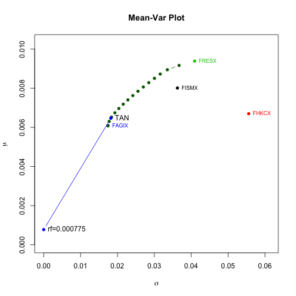

```r
    #
    # Generate the mean-var plot
    #
    MeanVar$plotPortfolio( null.portfolio )
```

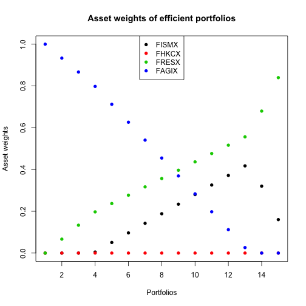

```r
    #
    # Plot and list asset weights
    #
    MeanVar$plotEffAssetWeights( null.portfolio, main="Asset weights of efficient portfolios" )
```

```r
    MeanVar$printEffPortfolios( null.portfolio )
```

```
##         [,1]   [,2]   [,3]   [,4]   [,5]   [,6]   [,7]   [,8]   [,9]  [,10]  [,11]  [,12]  [,13]  [,14]  [,15]
## FISMX 0.0000 0.0000 0.0000 0.0000 0.0500 0.1000 0.1400 0.1900 0.2300 0.2800 0.3300 0.3700 0.4200 0.3200 0.1600
## FHKCX 0.0000 0.0000 0.0000 0.0000 0.0000 0.0000 0.0000 0.0000 0.0000 0.0000 0.0000 0.0000 0.0000 0.0000 0.0000
## FRESX 0.0000 0.0700 0.1300 0.2000 0.2400 0.2800 0.3200 0.3600 0.4000 0.4400 0.4800 0.5200 0.5600 0.6800 0.8400
## FAGIX 1.0000 0.9300 0.8700 0.8000 0.7100 0.6300 0.5400 0.4500 0.3700 0.2800 0.2000 0.1100 0.0300 0.0000 0.0000
## er    0.0061 0.0063 0.0065 0.0067 0.0070 0.0072 0.0074 0.0076 0.0078 0.0081 0.0083 0.0085 0.0087 0.0089 0.0092
## stdev 0.0174 0.0178 0.0184 0.0193 0.0204 0.0216 0.0228 0.0242 0.0256 0.0270 0.0285 0.0300 0.0316 0.0335 0.0367
```

## Include Null Funds

```r
    #
    # Select "null portfolio" #10
    #
    portfolio$w.vec <- portfolio$eff.w.mat[,10]
    null.portfolio$w.vec <- null.portfolio$eff.w.mat[,10]

    #
    # Construct various combinations of optimal portfolio and null portfolio:
    #   100% optimal, 0% null
    #   90% optimal, 10% null
    #   80% optimal, 20% null
    #   70% optimal, 30% null
    #   60% optimal, 40% null
    #   50% optimal, 50% null
    #
    w0.vec <- portfolio$w.vec

    w10.vec <- portfolio$w.vec * 0.9
    w10.vec[ names(null.portfolio$w.vec) ] <- null.portfolio$w.vec * 0.1

    w20.vec <- portfolio$w.vec * 0.8
    w20.vec[ names(null.portfolio$w.vec) ] <- null.portfolio$w.vec * 0.2

    w30.vec <- portfolio$w.vec * 0.7
    w30.vec[ names(null.portfolio$w.vec) ] <- null.portfolio$w.vec * 0.3

    w40.vec <- portfolio$w.vec * 0.6
    w40.vec[ names(null.portfolio$w.vec) ] <- null.portfolio$w.vec * 0.4

    w50.vec <- portfolio$w.vec * 0.5
    w50.vec[ names(null.portfolio$w.vec) ] <- null.portfolio$w.vec * 0.5

    w.df <- data.frame(PORT=w0.vec,
                       PORT10=w10.vec,
                       PORT20=w20.vec,
                       PORT30=w30.vec,
                       PORT40=w40.vec,
                       PORT50=w50.vec)

    colSums(w.df)   # sanity check - all cols should sum to 1
```

```
##   PORT PORT10 PORT20 PORT30 PORT40 PORT50
##      1      1      1      1      1      1
```

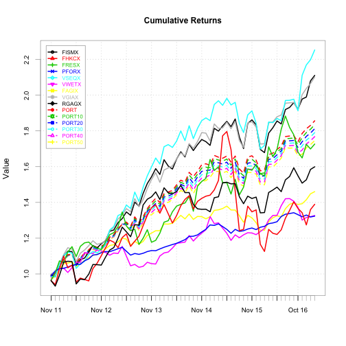

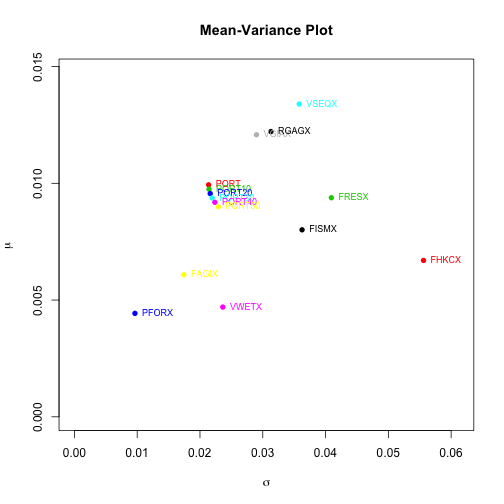

```r
    #
    # Generate monthly portfolio returns.
    #
    # selected.returns.zoo contains the asset returns (row=monthly return, column=asset)
    # w.df contains the asset weights (row=asset, column=port weights)
    #   (n x k) * (k x 5) -> (n x 5)    (row=monthly return, column=port
    # dot the fund monthly returns in each row in selected.returns.zoo
    # with the fund weights in each column of w.df
    # to get each portfolio's monthly returns
    #
    port.returns.zoo <- zoo( selected.returns.zoo %*% data.matrix(w.df),
                             order.by=index(selected.returns.zoo))

    #
    # Merge portfolio returns with individual asset returns
    #
    port.returns.zoo <- merge(selected.returns.zoo, port.returns.zoo)
    port.returns.stats.df <- My401k$computeSimpleReturnsStats( port.returns.zoo )   # dup effort here but oh well

    #
    # Plot cum returns and mean var of the portfolio + individual assets
    #
    My401k$plotCumReturnsAndMeanVar( port.returns.zoo,
                                     port.returns.stats.df,
                                     lty=c(rep(1,ncol(selected.returns.zoo)),
                                           rep(2,ncol(w.df)) ))
```

You can see why the “null.portfolio” funds were kept out of the optimal portfolio. Adding them in not only pushes down the mean return, it also pushes up the volatility. Nevertheless, there are good reasons why we should include them anyway:

1. Diversification!
2. Past returns don't necessarily predict future performance.

Better to be diversified than to bet all your money that the next 5 years will be just like the last 5 years.

## Future

- mean-cVaR analysis